# Analise de vendas de jogos eletrônicos

O primeiro jogo foi lançado em agosto de 1972, jogos da primeira geração eram desenvolvidos para um único console e o primeiro pertencia ao Magnavox Odyssey criado por Ralph Baer, o console ficou conhecido como Brown Box e o jogo consistia em um simples jogo de ping pong.

O projeto final da disciplina de Tecnologia da Informação realizado por *Fabrício Cavalcante Costa de Souza* é fundamentado em uma base que contém dados de jogos exclusivos de consoles desde de 1980 até 2016, chamada de *Vídeo Game Sales*, com informações sobre seu; ano de estreia no mercado, empresa desenvolvedora e editora, plataforma, gênero, vendas na América do Norte, Europa, Japão e o resto do mundo, vendas globais, nota que o jogo recebeu por críticos, nota que o jogo recebeu pelos jogadores, números de críticos e jogadores que colaboraram para a formação das notas, respectivamente, e classificação etária.

Estas características se encontram da seguinte maneira na base de dados (acompanhadas de seus resumos):

- Name: Nome do jogo
- Platform: Console no qual o jogo está sendo executado
- Year_of_Release: Ano do jogo lançado
- Genre: Categoria do jogo
- Publisher: Parte responsável por publicar o jogo
- NA_Sales: Vendas de jogos na América do Norte (em milhões de unidades)
- EU_Sales: Vendas de jogos na União Européia (em milhões de unidades)
- JP_Sales: Vendas de jogos no Japão (em milhões de unidades)
- Other_Sales: Vendas de jogos no resto do mundo, ou seja, na África, Ásia, excluindo o Japão, a Austrália, a Europa, excluindo a UE e a América do Sul (em milhões de unidades)
- Global_Sales:Total de vendas no mundo (em milhões de unidades)
- Critic_Score: Pontuação agregada compilada pela equipe Metacritic
- Critic_Count: O número de críticos usados na criação do Critic_score
- User_Score: Pontuação dos assinantes do Metacritic
- User_Count: Número de usuários que deram o user_score
- Developer: Parte responsável por criar o jogo
- Rating: As classificações ESRB (por exemplo, todos, adolescentes, adultos apenas, etc.)

## Carregando as Bibliotecas

```r
if(!require(tidyverse)){
    install.packages("tidyverse")
    library(tidyverse)
}

if(!require(ggrepel)){
    install.packages("ggrepel")
    library(ggrepel)
}

if(!require(gridExtra)){
    install.packages("gridExtra")
    library(gridExtra)
}

if(!require(plyr)){
    install.packages("plyr")
    library(plyr)
}
```

```r
library(readr)
library(dplyr)
library(tidyr)
library(data.table)
library(stringr)
library(magrittr)
library(ggplot2)
library(DataExplorer)
library(plotly)
library(caret)
library(randomForest)
```

## Base de Dados

```r
## apagar para exibir
df <- read.csv(file.choose(),stringsAsFactors = FALSE, sep =",")
#df <- read.csv(link, stringsAsFactors = FALSE, sep =",")
```

Essas são as primeiras 6 linhas de 16.719 da base de dados utilizada.

```r
head(df)
```

```
##                       Name Platform Year_of_Release        Genre Publisher
## 1               Wii Sports      Wii            2006       Sports  Nintendo
## 2        Super Mario Bros.      NES            1985     Platform  Nintendo
## 3           Mario Kart Wii      Wii            2008       Racing  Nintendo
## 4        Wii Sports Resort      Wii            2009       Sports  Nintendo
## 5 Pokemon Red/Pokemon Blue       GB            1996 Role-Playing  Nintendo
## 6                   Tetris       GB            1989       Puzzle  Nintendo
##   NA_Sales EU_Sales JP_Sales Other_Sales Global_Sales Critic_Score
## 1    41.36    28.96     3.77        8.45        82.53           76
## 2    29.08     3.58     6.81        0.77        40.24           NA
## 3    15.68    12.76     3.79        3.29        35.52           82
## 4    15.61    10.93     3.28        2.95        32.77           80
## 5    11.27     8.89    10.22        1.00        31.37           NA
## 6    23.20     2.26     4.22        0.58        30.26           NA
##   Critic_Count User_Score User_Count Developer Rating
## 1           51          8        322  Nintendo      E
## 2           NA                    NA
## 3           73        8.3        709  Nintendo      E
## 4           73          8        192  Nintendo      E
## 5           NA                    NA
## 6           NA                    NA
```

```r
glimpse(df)
```

```
## Observations: 16,719
## Variables: 16
## $ Name            <chr> "Wii Sports", "Super Mario Bros.", "Mario Kart...
## $ Platform        <chr> "Wii", "NES", "Wii", "Wii", "GB", "GB", "DS", ...
## $ Year_of_Release <chr> "2006", "1985", "2008", "2009", "1996", "1989"...
## $ Genre           <chr> "Sports", "Platform", "Racing", "Sports", "Rol...
## $ Publisher       <chr> "Nintendo", "Nintendo", "Nintendo", "Nintendo"...
## $ NA_Sales        <dbl> 41.36, 29.08, 15.68, 15.61, 11.27, 23.20, 11.2...
## $ EU_Sales        <dbl> 28.96, 3.58, 12.76, 10.93, 8.89, 2.26, 9.14, 9...
## $ JP_Sales        <dbl> 3.77, 6.81, 3.79, 3.28, 10.22, 4.22, 6.50, 2.9...
## $ Other_Sales     <dbl> 8.45, 0.77, 3.29, 2.95, 1.00, 0.58, 2.88, 2.84...
## $ Global_Sales    <dbl> 82.53, 40.24, 35.52, 32.77, 31.37, 30.26, 29.8...
## $ Critic_Score    <int> 76, NA, 82, 80, NA, NA, 89, 58, 87, NA, NA, 91...
## $ Critic_Count    <int> 51, NA, 73, 73, NA, NA, 65, 41, 80, NA, NA, 64...
## $ User_Score      <chr> "8", "", "8.3", "8", "", "", "8.5", "6.6", "8....
## $ User_Count      <int> 322, NA, 709, 192, NA, NA, 431, 129, 594, NA, ...
## $ Developer       <chr> "Nintendo", "", "Nintendo", "Nintendo", "", ""...
## $ Rating          <chr> "E", "", "E", "E", "", "", "E", "E", "E", "", ...
```

```r
summary(df)
```

```
##      Name             Platform         Year_of_Release
##  Length:16719       Length:16719       Length:16719
##  Class :character   Class :character   Class :character
##  Mode  :character   Mode  :character   Mode  :character
##
##
##
##
##     Genre            Publisher            NA_Sales          EU_Sales
##  Length:16719       Length:16719       Min.   : 0.0000   Min.   : 0.000
##  Class :character   Class :character   1st Qu.: 0.0000   1st Qu.: 0.000
##  Mode  :character   Mode  :character   Median : 0.0800   Median : 0.020
##                                        Mean   : 0.2633   Mean   : 0.145
##                                        3rd Qu.: 0.2400   3rd Qu.: 0.110
##                                        Max.   :41.3600   Max.   :28.960
##
##     JP_Sales        Other_Sales        Global_Sales      Critic_Score
##  Min.   : 0.0000   Min.   : 0.00000   Min.   : 0.0100   Min.   :13.00
##  1st Qu.: 0.0000   1st Qu.: 0.00000   1st Qu.: 0.0600   1st Qu.:60.00
##  Median : 0.0000   Median : 0.01000   Median : 0.1700   Median :71.00
##  Mean   : 0.0776   Mean   : 0.04733   Mean   : 0.5335   Mean   :68.97
##  3rd Qu.: 0.0400   3rd Qu.: 0.03000   3rd Qu.: 0.4700   3rd Qu.:79.00
##  Max.   :10.2200   Max.   :10.57000   Max.   :82.5300   Max.   :98.00
##                                                         NA's   :8582
##   Critic_Count     User_Score          User_Count       Developer
##  Min.   :  3.00   Length:16719       Min.   :    4.0   Length:16719
##  1st Qu.: 12.00   Class :character   1st Qu.:   10.0   Class :character
##  Median : 21.00   Mode  :character   Median :   24.0   Mode  :character
##  Mean   : 26.36                      Mean   :  162.2
##  3rd Qu.: 36.00                      3rd Qu.:   81.0
##  Max.   :113.00                      Max.   :10665.0
##  NA's   :8582                        NA's   :9129
##     Rating
##  Length:16719
##  Class :character
##  Mode  :character
##
##
##
##
```

## Limpandos os campos

```r
ind <- which(is.na(df$Critic_Score))
df$Critic_Score[ind] <- 0
```

```r
ind <- which(is.na(df$Critic_Count))
df$Critic_Count[ind] <- 0
```

```r
df$User_Score[df$User_Score == 'tbd' & !is.na(df$User_Score)] <- NA
df$User_Score <- as.numeric(as.character(df$User_Score))
df$User_Score[is.na(df$User_Score)] <- 0
```

```r
ind <- which(is.na(df$User_Count))
df$User_Count[ind] <- 0
```

```r
x3 <- sample(2000:2016, 269,replace = TRUE)
x3 <- as.vector(x3)
df$Year_of_Release[df$Year_of_Release == 'N/A'] <- NA
ind <- which(is.na(df$Year_of_Release))
df$Year_of_Release[ind] <- x3
```

```r
df$Developer[df$Developer == ''] <- NA
ind <- which(is.na(df$Developer))
```

```r
df$Rating[df$Rating == ''] <- NA
```

```r
df$Critic_Score <- df$Critic_Score/10
df$Year_of_Release <- as.integer(df$Year_of_Release)
glimpse(df)
```

```
## Observations: 16,719
## Variables: 16
## $ Name            <chr> "Wii Sports", "Super Mario Bros.", "Mario Kart...
## $ Platform        <chr> "Wii", "NES", "Wii", "Wii", "GB", "GB", "DS", ...
## $ Year_of_Release <int> 2006, 1985, 2008, 2009, 1996, 1989, 2006, 2006...
## $ Genre           <chr> "Sports", "Platform", "Racing", "Sports", "Rol...
## $ Publisher       <chr> "Nintendo", "Nintendo", "Nintendo", "Nintendo"...
## $ NA_Sales        <dbl> 41.36, 29.08, 15.68, 15.61, 11.27, 23.20, 11.2...
## $ EU_Sales        <dbl> 28.96, 3.58, 12.76, 10.93, 8.89, 2.26, 9.14, 9...
## $ JP_Sales        <dbl> 3.77, 6.81, 3.79, 3.28, 10.22, 4.22, 6.50, 2.9...
## $ Other_Sales     <dbl> 8.45, 0.77, 3.29, 2.95, 1.00, 0.58, 2.88, 2.84...
## $ Global_Sales    <dbl> 82.53, 40.24, 35.52, 32.77, 31.37, 30.26, 29.8...
## $ Critic_Score    <dbl> 7.6, 0.0, 8.2, 8.0, 0.0, 0.0, 8.9, 5.8, 8.7, 0...
## $ Critic_Count    <dbl> 51, 0, 73, 73, 0, 0, 65, 41, 80, 0, 0, 64, 0, ...
## $ User_Score      <dbl> 8.0, 0.0, 8.3, 8.0, 0.0, 0.0, 8.5, 6.6, 8.4, 0...
## $ User_Count      <dbl> 322, 0, 709, 192, 0, 0, 431, 129, 594, 0, 0, 4...
## $ Developer       <chr> "Nintendo", NA, "Nintendo", "Nintendo", NA, NA...
## $ Rating          <chr> "E", NA, "E", "E", NA, NA, "E", "E", "E", NA, ...
```

Nessa parte realizamos a limpeza do dados, transformando os espaços vazios em NAs (falta de dado), preenchendo o campo dos anos e modificando a coluna de Critic_Score para ficar compatível com User_Score.

### 1.Vendas totais ao redor do mundo para Publisher

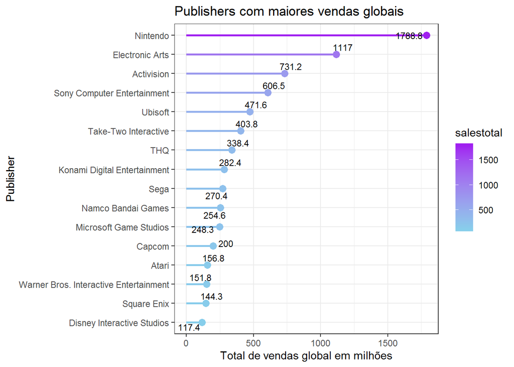

Como são mais de 500 Publisher, somente os Publisher com vendas totais superiores à 100 milhões de unidades foram analisados. Vemos aqui que a Nintendo é umas da que mais fatura.

### 2.Vendas totais ao redor do mundo para cada classificação etária

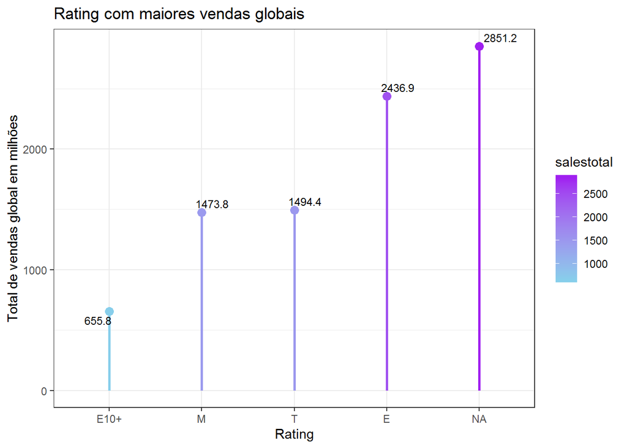

As classificações etárias são os dados com maior número de NAs, tornando o NA campeã das vendas totais. A análise novamente foi feita com mais de 100 milhões de unidades por conta de algumas classificações não possuir sequer 10 milhões de unidades.

### 3.Vendas totais dos jogos através dos anos

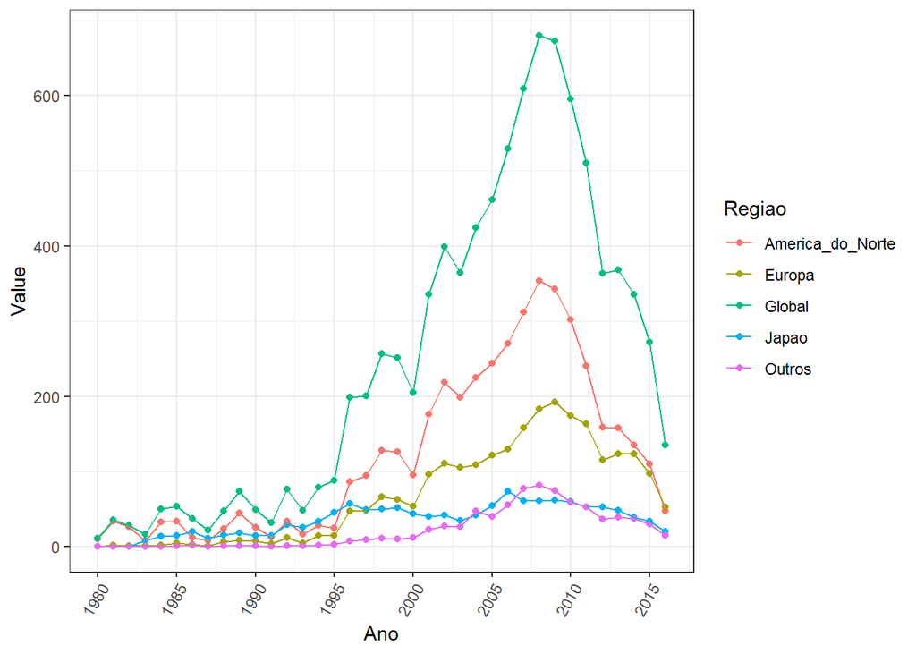

### 4.Qual o gênero com com a maior quantidade de jogos publicados?

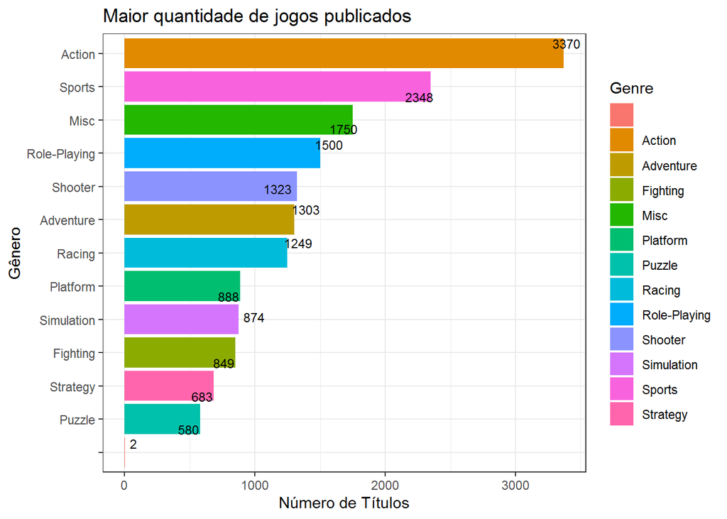

O único gênero não nomeado é o gênero sem classificação determinada que veio na base de dados.Verificamos aqui que jogos de ação, sport e variados possuem a maior quantidade de títulos.

### 5.Influência nas vendas pelo gênero de jogos

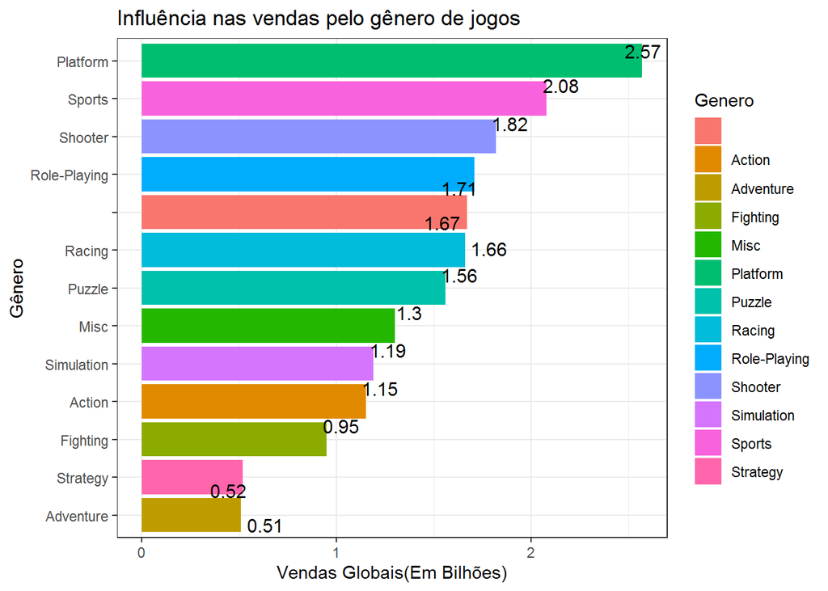

Como na pergunta anterior, o gênero que está com o espaço vazio é o gênero sem classificação. Vemos aqui que o campeão em vendas são os jogos de Plataforma, mesmo tendo a quantidade de jogos menor que os jogos de ação.

### 6.Publisher com o maior número de jogos produzidos

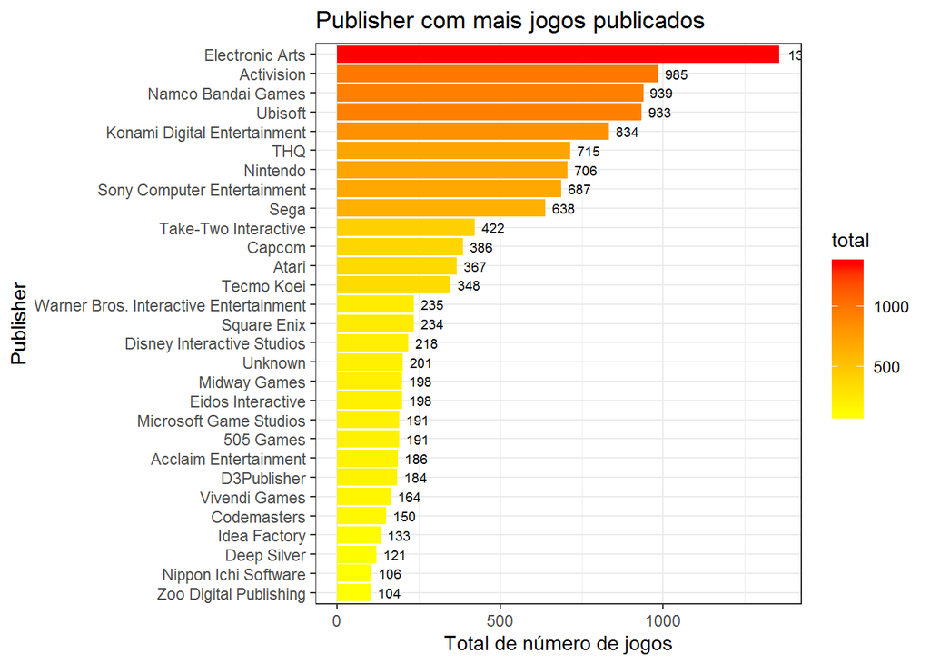

Seguindo à lógica de tornar à análise menos extensa, somente os Publisher com número de jogos feitos maior do que 100 entraram na avaliação. Aqui Eletronic Arts sai em primeiro lugar, ja que ela é uma das principais no desenvolvimento de jogos de sports, ação e shooter.

### 7.Os jogos mais bem avaliados

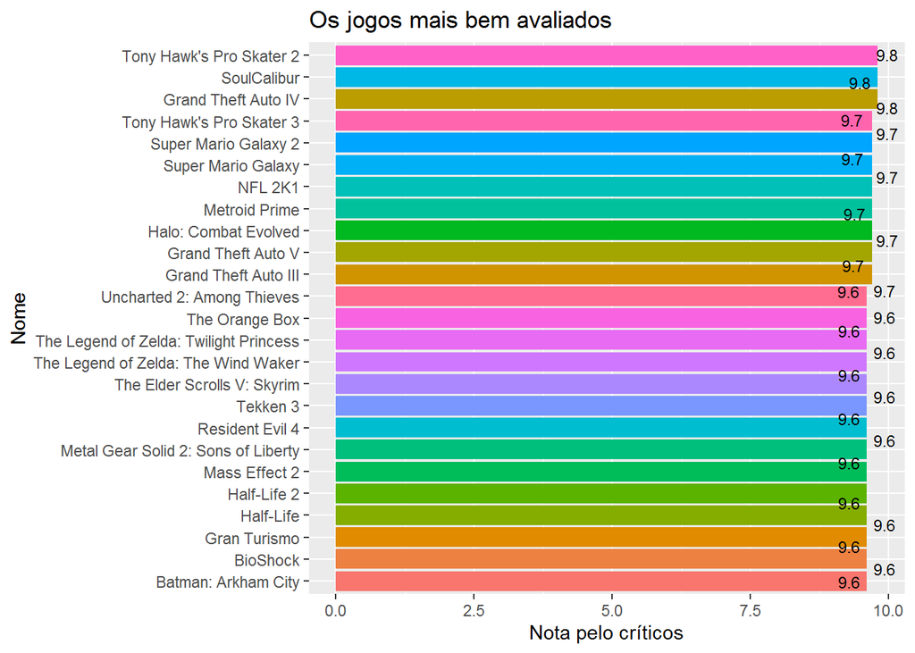

A avaliação se baseou somente no Critic_Score maior que 9,5 por conta da quantidade de jogos que aparecem e também por conta do número de avaliadores, com o User_Score, alguns jogos recebe nota alta, porém só tem um único avaliador, por conta disso esta avaliação foi descartada.

### 8.Uma boa avaliação influencia nas vendas?

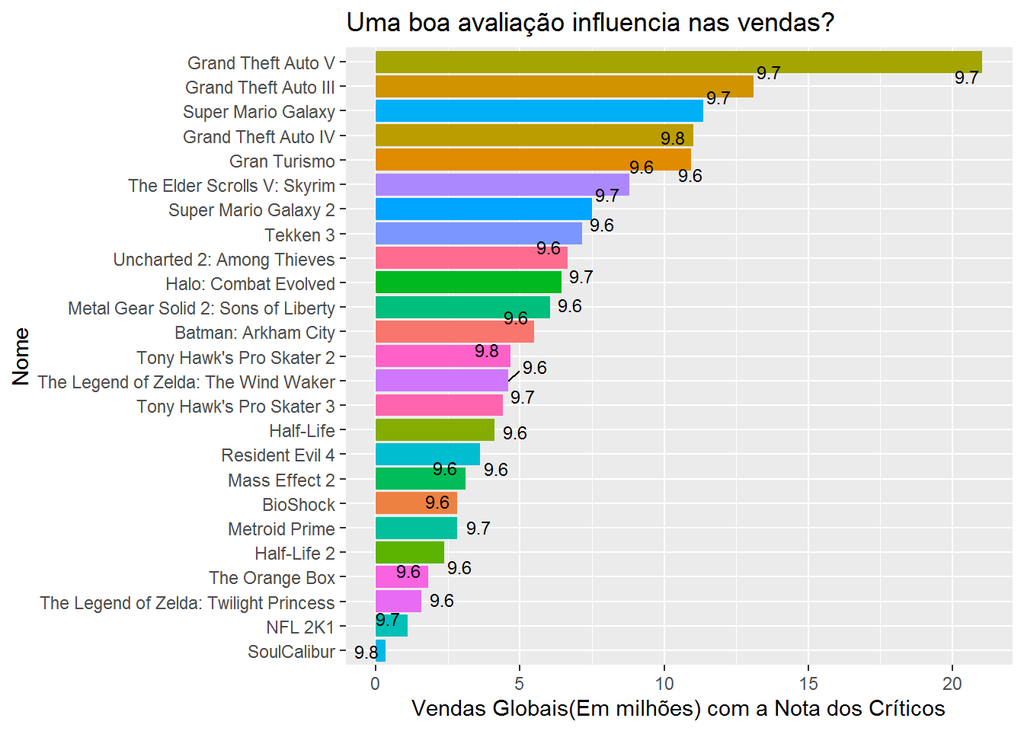

Novamente o critério de somente Critic_Score entrou na avaliação por conta de ter mais um avaliador, diferente do User_Score.

### 9. Qual a plataforma com a maior quantidade de venda?

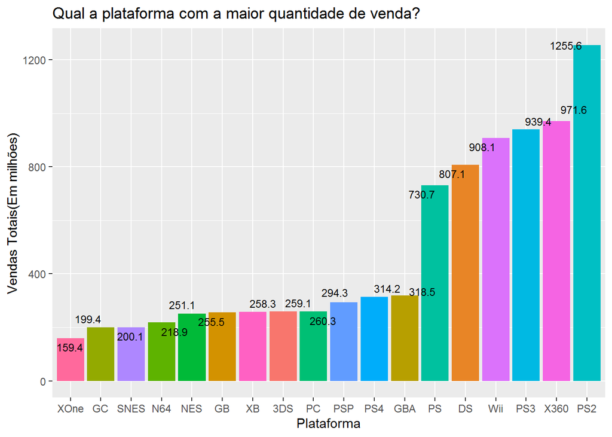

Os jogos possuem dados desde 1980, então é normal ter plataforma antigas, para uma análise melhor foi retirado todas as plataformas com menos de 100 milhões de unidades, tornando o gráfico bem menos denso. Aqui podemos notar que o PS2 teve uma quantidade enorme de vendas, ultrapassando até mesmo seu sucessor o PS3 e superando um outro console com poder de processamento superior Xbox 360.

## Extras - Parte 4 - Regressão & Random Forest

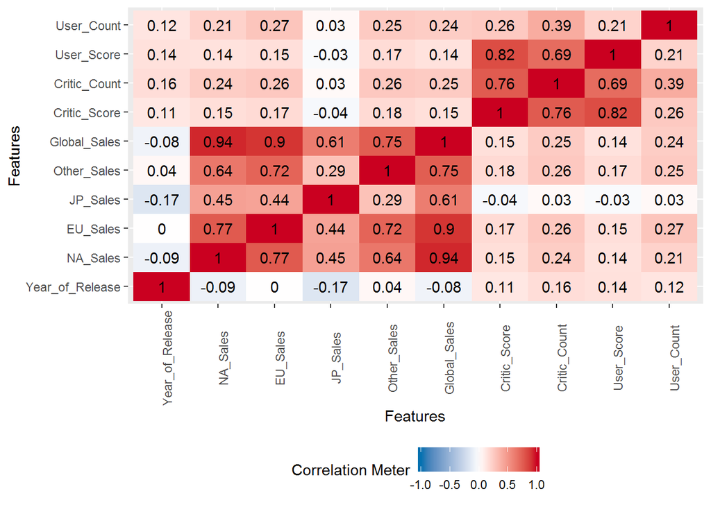

Mapa de correlação dos dados, nesse gráfico, tentamos encontrar variáveis que tenham uma correlação.

### Modelo de Treino

```r
set.seed(123)
ps3set <- subset(df, Platform=="PS3")
index <- sample(1:nrow(ps3set),size = 0.7*nrow(ps3set))
ps3set.train <- ps3set[index,]
ps3set.test <- ps3set[-index,]
```

Vamos dividir a base em um modelo de teste e treino e tentar prever algo relevante com base nas nossas variáveis, para tentarmos ser mais precisos, usamos a Plataforma “PS3” e vamos utilizar dois algortimos de machine learning, regressão linear e random forest para tentar verificar se os resultados permanecem iguais no fim.

### Regressão Linear

```r
ps3.lm <- lm(formula= NA_Sales ~ User_Count +
            User_Score + Critic_Count + Critic_Score +
            Year_of_Release, data=ps3set.train)
summary(ps3.lm)
```

```
##
## Call:
## lm(formula = NA_Sales ~ User_Count + User_Score + Critic_Count +
##     Critic_Score + Year_of_Release, data = ps3set.train)
##
## Residuals:
##     Min      1Q  Median      3Q     Max
## -3.6213 -0.1554 -0.0594  0.0182  4.0553
##
## Coefficients:
##                   Estimate Std. Error t value Pr(>|t|)
## (Intercept)      2.466e+01  1.163e+01   2.119 0.034350 *
## User_Count       7.059e-04  2.886e-05  24.458  < 2e-16 ***
## User_Score      -5.020e-03  7.293e-03  -0.688 0.491425
## Critic_Count     1.249e-03  1.113e-03   1.123 0.261672
## Critic_Score     2.777e-02  7.971e-03   3.484 0.000517 ***
## Year_of_Release -1.223e-02  5.784e-03  -2.114 0.034770 *
## ---
## Signif. codes:  0 '***' 0.001 '**' 0.01 '*' 0.05 '.' 0.1 ' ' 1
##
## Residual standard error: 0.4043 on 925 degrees of freedom
## Multiple R-squared:  0.5309, Adjusted R-squared:  0.5284
## F-statistic: 209.4 on 5 and 925 DF,  p-value: < 2.2e-16
```

Tivemos que usar mais de uma variável para que nosso modelo tivesse relevância e para que pudessemos ajustar o R-Squared para um valor aceitável.

```r
ps3.lmimp <- varImp(ps3.lm)
ps3.lmimp <- ps3.lmimp[order(-ps3.lmimp$Overall),, drop=FALSE]

ps3set.test.predlm <- exp(predict(ps3.lm,ps3set.test))-1
```

Criamos uma tabela de importância para o modelo linear e realizamos a previsão através do predict

### Random Forest

```r
ps3.rf <- randomForest(NA_Sales ~ User_Count + User_Score + Critic_Count + Critic_Score +
            Year_of_Release, data = ps3set.train, importance = TRUE)
```

Usamos um outro algoritmo chamado random forest que através de nossas variáveis passada, faz diversas combinações para que consiga encontrar o modelo com a maior acurácia e mais precisão.

```r
ps3.rfimp <- as.data.frame(sort(importance(ps3.rf)[,1],decreasing = TRUE),optional = T)
names(ps3.rfimp) <- "PS3 %"
```

Realizamos o mesmo processo de construção das tabelas de importância, mas agora para o modelo de random forest.

```r
ps3set.test.predrf <- predict(ps3.rf,ps3set.test)
```

Realizamos a previsão chamando a função predict para o random forest.

```r
ps3set.allpred <- data.frame(Atual = ps3set.test$NA_Sales,
                              linear.regression = ps3set.test.predlm,
                              random.forest = ps3set.test.predrf)
ps3set.allpred <- gather(ps3set.allpred,key = model,value = Previsoes,2:3)
```

Realizamos a união dos modelos de regressão linear e random forest com base na variável NA_Sales e também para que possamos plotar no ggplot de forma mais clara.

### Plotando no ggplot os dois modelos

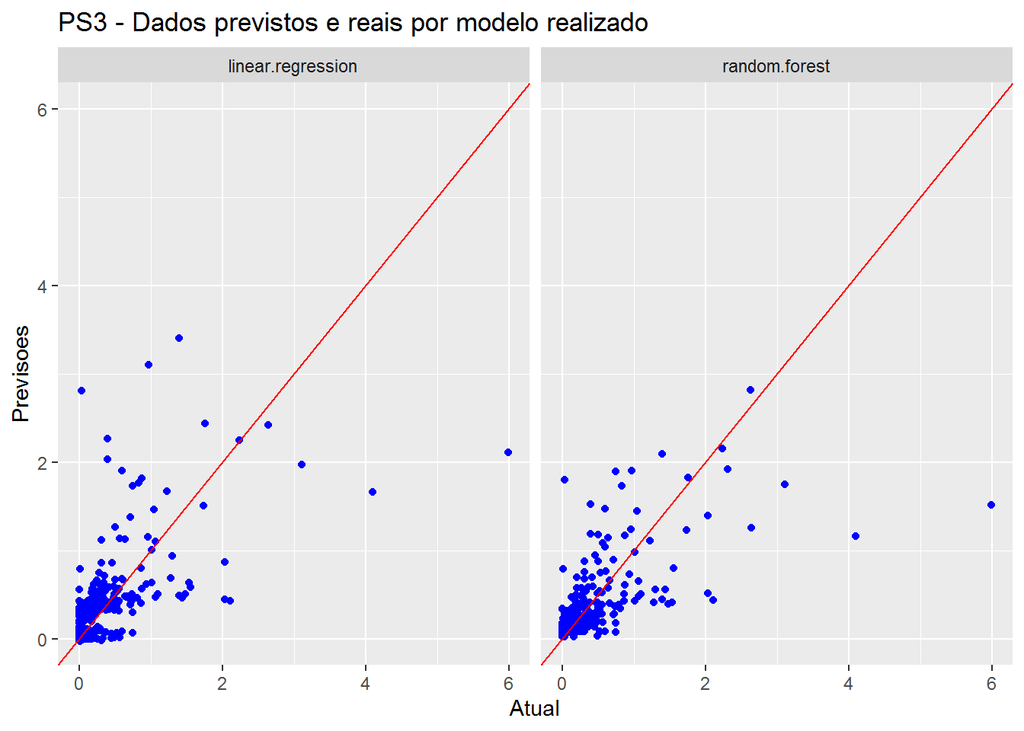

Como podemos ver, o modelo random forest foi o que melhor se adaptou ao nosso modelo.